# An introduction to R for psychologists

### Part 1 : General intro

## Summary of the first part

- Presentation and ecosystem
  - Presentation and usage
  - Benefits and caveats
  - comparison with other programming languages
- How R works :
  - Data types and objects
  - Functions
  - Plotting
  - Libraries

R is an **essential** programming language for quantitative analysis of data

The principle is to translate instructions/commands into outputs

```r
print('hello world')
```

```
[1] "hello world"
```

```r
1+1
```

2

Oriented towards statistical analysis

```r
t.test
```

```
function (x, ...)
UseMethod("t.test")
```

## Programming environment

Programming in R comes with a lot of flavours :

- base R

[figure not shown]

- R studio

[figure not shown]

- Jupyter ...

[figure not shown]

## What are the *benefits* of R :

- Reproducible analysis (including for you)
- Peer review (in theory)
- Cooperative science (packages, public repository, code sharing, R community)
- Integrated analysis (data wrangling/cleaning, plotting, statistics, EEG ?,etc.)
- Large possibilities (simulating entire experiments, writing papers, grading,etc.)

## What are the *caveats* of R :

- Error prone (but see excel, [Reinhart-Rogoff error](https://theconversation.com/the-reinhart-rogoff-error-or-how-not-to-excel-at-economics-13646?utm_source=twitter&utm_medium=twitterbutton) )
- Package maintenance and bugs (but see [issue on Github](https://github.com/easystats/performance/issues/270) resolved in <1 day)
- steep learning curve (climbing can feel exhausting but you progress quickly)

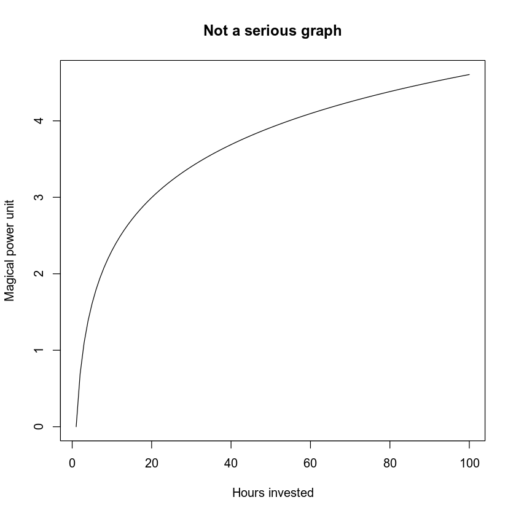

```r
plot(1:100, log(1:100), type = "l", main='Not a serious graph',
     xlab ='Hours invested', ylab = "Magical power unit")
```

Compared to other programming languages :

```r
'R' > 'Matlab ?'
```

TRUE

# How R works

- Data types and objects
- Functions
- Plotting
- Libraries

# How R works

- Data types of single elements

```r
1 + 1
```

2

# How R works

- Base function on single elements

```r
# Assigning
a <- 2 # or a =2
b <- a+a
print(b)
```

```
[1] 4
```

```r
#Reassigning and re-reassigning
a <- a + a
print(a)
```

```
[1] 4
```

```r
ls()
```

1. 'a'

2. 'b'

```r
#removing
rm(a)
```

```r
ls()
```

'b'

```r
#Operations
sqrt(4)
```

2

# How R works

- Collection of elements (or objects) :

| Name | dim() | type |
| --- | --- | --- |
| vectors | n | homogeneous |
| matrix | n x m | homogeneous |
| list | n | heterogeneous |
| data.frames | n x m | heterogeneous |
| factors | n | characters (specific to R) |

# How R works

- base function on collections

```r
a <- c(1,2,3)
```

```r
length(a)
```

3

```r
#Indexing
print(a[1]) # 1-indexed
#assigning
a[1] <- 99
print(a[1])
```

```
[1] 1
[1] 99
```

```r
#Operations on collections
a <- c(1,2,3)
sqrt(a)
```

1. 1

2. 1.4142135623731

3. 1.73205080756888

```r
sd(a)
```

1

```r
a <- matrix(data = 1:9, nrow=3)
```

```r
print(a)
```

```
     [,1] [,2] [,3]
[1,]    1    4    7
[2,]    2    5    8
[3,]    3    6    9
```

```r
dim(a)
```

1. 3

2. 3

```r
print(a[1,3])
print(a[1,])
```

```
[1] 7
[1] 1 4 7
```

```r
#Operations
sqrt(a)
```

A matrix: 3 × 3 of type dbl

| 1.000000 | 2.000000 | 2.645751 |
| --- | --- | --- |
| 1.414214 | 2.236068 | 2.828427 |
| 1.732051 | 2.449490 | 3.000000 |

```r
#Operations
mean(a[1,])
```

4